# ZmFd4 / ZmFd9 promoter primers across PanAnd teosintes

Author

thegemmalab@ncsu.edu

Published

October 5, 2026

**Goal.** Primers that amplify the region upstream of the ATG of the maize ferredoxins **ZmFd4** (`Zm00001eb083950`) and **ZmFd9** (`Zm00001eb421930`) in every published PanAnd *Zea* teosinte assembly, so the region can be resequenced (cf. Jia *et al.* 2025, who resequenced a 2.9-kb ZmFd4 fragment and found InDel194, a 604-bp deletion upstream of the ATG).

[figure not shown]

Analysis overview: each block is a group of notebook sections (§); the red line is the primer design, the dashed grey lines are the checks. Source: `docs/pipeline.mmd` (nf-metro).

## Bottom line

**Design rules.**

- **Reverse primer** in the **first CDS exon** (in B73 v5 both genes start with a non-coding 5′UTR exon; the ATG is in exon 2, which holds the whole CDS).
- Primer sites are chosen by **conservation, not coordinates**: a primer must sit on alignment columns that are identical and gap-free in **every** accession (pass 1). Only if pass 1 finds nothing are SNP columns allowed, as IUPAC degenerate bases, with an invariant 3′ 5 nt (pass 2).
- **Product ≤ 3,000 bp in every accession** (a longer PCR is impractical, and capping on B73 alone would lose any longer allele). Among pairs under the cap, prefer the largest product in the *shortest* accession (coverage), then Primer3 penalty. For ZmFd4 the 604-bp InDel194 is wider than a 2.5–3-kb window, so Hap2 accessions give ~600 bp less than Hap1.
- **Alternatives are independent:** each backup pair uses forward and reverse sites ≥ 50 bp away from those of the pairs already chosen.
- **Specificity:** forward e-PCR over each whole genome, as in `primermu`.

```r
suppressPackageStartupMessages({
  library(Biostrings)                       # first, so dplyr/purrr verbs (slice, filter, reduce) win
  library(gggenomes); library(ggplot2); library(readr); library(dplyr); library(tidyr)
  library(stringr); library(purrr); library(ape); library(ggtree)
})

MODE <- params$mode
stopifnot(MODE %in% c("stub", "full"))
REF  <- if (MODE == "stub") "tests/fixtures" else "/rsstu/users/r/rrellan/BZea/ref"
ACC  <- read_tsv(if (MODE == "stub") "config/accessions_stub.tsv" else "config/accessions.tsv",
                 show_col_types = FALSE)
WORK <- file.path("work", MODE)
RES  <- if (MODE == "stub") file.path(WORK, "results") else "results"
for (d in file.path(WORK, c("", "fai", "blastdb", "loci", "aln", "p3", "epcr")))
  dir.create(d, showWarnings = FALSE, recursive = TRUE)
dir.create(RES, showWarnings = FALSE, recursive = TRUE)
THREADS <- as.integer(Sys.getenv("SLURM_CPUS_PER_TASK", "4"))

GENES <- tibble(gene = c("ZmFd4", "ZmFd9"), b73_id = c("Zm00001eb083950", "Zm00001eb421930"))
UP <- 6000L; DOWN <- 1000L                 # locus = ATG - UP .. CDS end + DOWN, in gene orientation
PRODUCT_MAX <- 3000L                       # hard cap, every accession
# ZmFd4 InDel194 as documented by Jia et al. 2025: a 604-bp indel ending 194 bp upstream of the ATG; B73 carries
# the full sequence (Hap1). Positions relative to the ATG (A = 0) and in B73 locus coordinates (ATG at UP + 1).
INDEL194_REL <- c(-798L, -195L)
INDEL194_LOC <- UP + 1L + INDEL194_REL
P3_RANGE <- c(1500L, PRODUCT_MAX)          # Primer3 range on the B73 template; the cap is re-checked per accession
N_PAIRS <- 3L; MIN_SEP <- 50L
# one % identity colour scale for every figure and both genes: blue, darker = more similar; <= 85 % shown as 85
ID_LIM <- c(85, 100)
id_scale <- function(aes = "colour", name = "% identity\nto B73")
  continuous_scale(aes, palette = scales::pal_seq_gradient("#56B1F7", "#132B43"), limits = ID_LIM, oob = scales::squish,
                   breaks = seq(85, 100, 5), labels = c("≤85", "90", "95", "100"), name = name)

sh  <- function(cmd) system2("bash", c("-c", shQuote(cmd)), stdout = TRUE, stderr = TRUE)
out <- function(cmd) system2("bash", c("-c", shQuote(cmd)), stdout = TRUE, stderr = FALSE)
tools <- c("samtools", "blastn", "makeblastdb", "mafft", "primer3_core", "e-PCR", "FastTree")
miss <- tools[Sys.which(tools) == ""]
if (length(miss)) stop("missing tools: ", paste(miss, collapse = ", "))
cat(sprintf("mode = %s | %d accessions | reference dir %s\n", MODE, nrow(ACC), REF))
```

```
mode = full | 10 accessions | reference dir /rsstu/users/r/rrellan/BZea/ref
```

## 1. Inputs

The reference data are an **assumed starting point** (see README, “Inputs”): for every accession in /rsstu/users/r/rrellan/BZea/ref, a plain-FASTA genome with its nucleotide BLAST DB, its gene annotation, and its proteome with a samtools index and a protein BLAST DB (all DBs `-parse_seqids`). Preparing them (download, decompression, indexing) is done once outside this notebook. The three expensive steps — ortholog searches (§3), alignment (§5) and whole-genome e-PCR (§8) — are cached by knitr and rerun only when their inputs change (keyed on a hash of the queries, loci and candidate pairs), so re-rendering after a text or figure change takes about a minute. Only the genome `.fai` indexes are written here, to `work/`; nothing is ever written to /rsstu/users/r/rrellan/BZea/ref.

```r
ACC <- ACC %>% mutate(
  fa   = file.path(REF, genome),
  fai  = file.path(WORK, "fai", paste0(accession, ".fa.fai")),
  gff  = file.path(REF, gff),
  db   = sub("\\.fa$", "", fa),
  prot = file.path(REF, protein),
  pdb  = sub("\\.fa$", "", prot),
  te   = ifelse(is.na(te) | te == "", NA_character_, file.path(REF, te)))   # EDTA TE GFF, sorted + bgzip + tabix; optional
has_db <- function(p, k = "n") any(file.exists(paste0(p, sprintf(c(".%ssq", ".%sal", ".00.%ssq"), k))))
no_db  <- ACC$db[!map_lgl(ACC$db, has_db)]
no_pdb <- ACC$pdb[!map_lgl(ACC$pdb, has_db, k = "p")]
files  <- c(ACC$fa, ACC$gff, ACC$prot, paste0(ACC$prot, ".fai"), na.omit(ACC$te), paste0(na.omit(ACC$te), ".tbi"))
missing_in <- c(files[!file.exists(files)], if (length(no_db)) paste(no_db, "(nucleotide BLAST DB)"),
                if (length(no_pdb)) paste(no_pdb, "(protein BLAST DB)"))
if (length(missing_in)) stop("missing inputs (prepare them first, see README):\n", paste(missing_in, collapse = "\n"))
for (i in seq_len(nrow(ACC))) with(ACC[i, ], if (!file.exists(fai)) sh(sprintf("samtools faidx --fai-idx %s %s", shQuote(fai), shQuote(fa))))

grab <- function(acc, chr, s, e, rc = FALSE) {
  a <- ACC[ACC$accession == acc, ]
  o <- out(sprintf("samtools faidx --fai-idx %s %s %s:%d-%d", shQuote(a$fai), shQuote(a$fa), chr, s, e))
  d <- DNAString(toupper(paste(o[-1], collapse = "")))
  if (rc) reverseComplement(d) else d
}
get_prot <- function(acc, ids) {                            # proteins by ID from the indexed proteome
  tf <- tempfile(fileext = ".faa")
  writeLines(out(sprintf("samtools faidx %s %s", shQuote(ACC$prot[ACC$accession == acc]), paste(shQuote(ids), collapse = " "))), tf)
  x <- readAAStringSet(tf); names(x) <- sub(" .*", "", names(x)); x
}
prot_ids <- function(acc) read_tsv(paste0(ACC$prot[ACC$accession == acc], ".fai"), col_names = "id",
                                   col_types = cols_only(id = "c"), show_col_types = FALSE)$id
gene_of <- function(pid) sub("(_P\\d+|\\.\\d+)$", "", pid)                 # Zx..._P001 -> Zx...; Helixer x.1 -> x
tx_of   <- function(pid) ifelse(grepl("_P\\d+$", pid), sub("_P(\\d+)$", "_T\\1", pid), pid)
pid_of  <- function(tx)  ifelse(grepl("_T\\d+$", tx), sub("_T(\\d+)$", "_P\\1", tx), tx)   # Helixer: protein ID = transcript ID
# canonical transcript of each gene: canonical_transcript=1 (MaizeGDB / PanAnd); Helixer has one transcript per gene
canonical <- function(gm) gm %>% filter(type == "mRNA") %>%
  arrange(Parent, desc(grepl("canonical_transcript=1", attr)), ID) %>% distinct(Parent, .keep_all = TRUE) %>%
  transmute(gene_id = Parent, tx = ID, pid = pid_of(ID))
gff_cols <- c("seqid","src","type","start","end","score","strand","phase","attr")
read_te <- function(acc, chr, s, e) {                      # EDTA TE features overlapping chr:s-e (tabix)
  f <- ACC$te[ACC$accession == acc]
  if (is.na(f)) return(NULL)
  txt <- out(sprintf("tabix %s %s:%d-%d", shQuote(f), chr, max(1L, s), e))
  if (!length(txt)) return(NULL)
  read_tsv(I(txt), col_names = gff_cols, col_types = "ccciicccc") %>%
    mutate(Name = str_match(attr, "Name=([^;]+)")[, 2], Classification = str_match(attr, "Classification=([^;]+)")[, 2]) %>%
    filter(!is.na(Classification), type != "repeat_region")
}
read_gff <- function(gff, filter_awk) {
  cat_cmd <- if (grepl("\\.gz$", gff)) "gzip -dc" else "cat"
  txt <- out(sprintf("%s %s | awk -F'\\t' '%s'", cat_cmd, shQuote(gff), filter_awk))
  if (!length(txt)) return(NULL)
  read_tsv(I(txt), col_names = gff_cols, col_types = "ccciicccc") %>%
    mutate(ID = str_match(attr, "(?:^|;)ID=([^;]+)")[, 2], Parent = str_match(attr, "Parent=([^;]+)")[, 2])
}
knitr::kable(ACC %>% transmute(accession, taxon, annotation, genome_db = basename(db), proteome = basename(prot)))
```

| accession | taxon | annotation | genome_db | proteome |
| --- | --- | --- | --- | --- |
| B73 | Zea mays ssp. mays (reference) | MaizeGDB Zm00001eb.1 | Zm-B73-REFERENCE-NAM-5.0 | Zm-B73-REFERENCE-NAM-5.0_Zm00001eb.1.protein.fa |
| TIL01 | Zea mays ssp. parviglumis | PanAnd Zv00001aa.1 | Zv-TIL01-REFERENCE-PanAnd-1.0 | Zv-TIL01-REFERENCE-PanAnd-1.0_Zv00001aa.1.protein.fa |
| TIL11 | Zea mays ssp. parviglumis | PanAnd Zv00002aa.1 | Zv-TIL11-REFERENCE-PanAnd-1.0 | Zv-TIL11-REFERENCE-PanAnd-1.0_Zv00002aa.1.protein.fa |
| TIL18 | Zea mays ssp. mexicana | PanAnd Zx00002aa.1 | Zx-TIL18-REFERENCE-PanAnd-1.0 | Zx-TIL18-REFERENCE-PanAnd-1.0_Zx00002aa.1.protein.fa |
| TIL25 | Zea mays ssp. mexicana | PanAnd Zx00003aa.1 | Zx-TIL25-REFERENCE-PanAnd-1.0 | Zx-TIL25-REFERENCE-PanAnd-1.0_Zx00003aa.1.protein.fa |
| RIMHU001 | Zea mays ssp. huehuetenangensis | PanAnd Zh00001aa.1 | Zh-RIMHU001-REFERENCE-PanAnd-1.0 | Zh-RIMHU001-REFERENCE-PanAnd-1.0_Zh00001aa.1.protein.fa |
| Gigi | Zea diploperennis | PanAnd Zd00001aa.1 | Zd-Gigi-REFERENCE-PanAnd-1.0 | Zd-Gigi-REFERENCE-PanAnd-1.0_Zd00001aa.1.protein.fa |
| Momo | Zea diploperennis | PanAnd Zd00003aa.1 | Zd-Momo-REFERENCE-PanAnd-1.0 | Zd-Momo-REFERENCE-PanAnd-1.0_Zd00003aa.1.protein.fa |
| PI615697 | Zea nicaraguensis | PanAnd Zn00001aa.1 | Zn-PI615697-REFERENCE-PanAnd-1.0 | Zn-PI615697-REFERENCE-PanAnd-1.0_Zn00001aa.1.protein.fa |
| RIL003 | Zea luxurians | Helixer (no PanAnd annotation) | Zl-RIL003-REFERENCE-PanAnd-1.0 | Zl-RIL003-REFERENCE-PanAnd-1.0_helixer.protein.fa |

## 2. B73 queries

The B73 protein of each gene (from the B73 proteome) drives the ortholog search; its CDS is used only to find copies that have no gene model.

```r
b73 <- ACC %>% filter(accession == "B73")
b73_models <- read_gff(b73$gff, sprintf("$9 ~ /(%s)/", paste(GENES$b73_id, collapse = "|")))
GENES$b73_pid <- canonical(b73_models)$pid[match(GENES$b73_id, canonical(b73_models)$gene_id)]
qp <- get_prot("B73", GENES$b73_pid); names(qp) <- GENES$gene
qpfa <- file.path(WORK, "query_proteins.faa"); writeXStringSet(qp, qpfa)

cds_q <- GENES %>% rowwise() %>% mutate(seq = {
  cds <- b73_models %>% filter(type == "CDS", Parent == tx_of(b73_pid))
  rc <- cds$strand[1] == "-"
  cds <- if (rc) arrange(cds, desc(start)) else arrange(cds, start)
  as.character(do.call(xscat, map(seq_len(nrow(cds)), ~ grab("B73", cds$seqid[.x], cds$start[.x], cds$end[.x], rc))))
}) %>% ungroup()
qfa <- file.path(WORK, "cds_queries.fa")
writeLines(paste0(">", cds_q$gene, "\n", cds_q$seq), qfa)
knitr::kable(GENES %>% transmute(gene, b73_id, aa = Biostrings::width(qp)[match(gene, names(qp))], cds_bp = nchar(cds_q$seq)),
             caption = "Queries: canonical-transcript protein and CDS of each B73 gene.")
```

Queries: canonical-transcript protein and CDS of each B73 gene.

| gene | b73_id | aa | cds_bp |
| --- | --- | --- | --- |
| ZmFd4 | Zm00001eb083950 | 155 | 468 |
| ZmFd9 | Zm00001eb421930 | 148 | 444 |

## 3. Orthologs: protein reciprocal best hits, one locus per haplotype

Standard protein-level orthology (as in OrthoMCL / OrthoFinder / GENESPACE, reduced to two genes):

1. **Annotated candidates:** `blastp` of the B73 Fd4 and Fd9 proteins against each proteome; every gene with a hit covering ≥ 40 % of the query is a candidate (its best-scoring isoform).
2. **Unannotated candidates:** genome `blastn` of the B73 CDSs; a hit that overlaps no gene model is translated (extended to the query CDS length) and added. These copies — typically on `alt-*` scaffolds — are absent from every proteome.
3. **Reciprocal best hit:** every candidate protein is searched back against the **whole B73 proteome**; it is an ortholog of ZmFd4 / ZmFd9 only if its best hit is that gene.
4. **Locus per haplotype:** primary = best RBH copy on the B73-matching chromosome, else on any other `chr*`, else the best anywhere, flagged **unplaced**. The best remaining RBH copy off the primary chromosomes is that accession’s second haplotype (`<accession>_alt`), which primers must bind too. The full gene tree (§3b) shows every candidate so each call can be judged.

```r
bl6 <- function(cmd, cols) { o <- out(cmd); if (!length(o)) return(NULL)
  read_tsv(I(o), col_names = cols, show_col_types = FALSE, col_types = cols(.default = "c")) %>% type_convert(guess_integer = TRUE) }
bp_cols <- c("qseqid","sseqid","pident","length","qstart","qend","sstart","send","evalue","bitscore","qlen","slen")
blastp <- function(q, db, n = 100) bl6(sprintf("blastp -query %s -db %s -evalue 1e-10 -max_target_seqs %d -num_threads %d -outfmt '6 %s'",
                                               shQuote(q), shQuote(db), n, THREADS, paste(bp_cols, collapse = " ")), bp_cols)

# 1. annotated candidates: genes hit through any isoform, represented by their canonical-transcript protein
fwd <- map_dfr(ACC$accession, function(a) blastp(qpfa, ACC$pdb[ACC$accession == a]) %>% mutate(genome = a)) %>%
  mutate(sseqid = sub("^lcl\\|", "", sseqid), qcov = (qend - qstart + 1) / qlen, gene_id = gene_of(sseqid)) %>%
  filter(qcov >= 0.4) %>% group_by(genome, gene_id) %>% slice_max(bitscore, n = 1, with_ties = FALSE) %>% ungroup()
ann <- map_dfr(unique(fwd$genome), function(a) {
  f <- fwd %>% filter(genome == a)
  gm <- read_gff(ACC$gff[ACC$accession == a], sprintf("$9 ~ /(%s)/", paste(unique(f$gene_id), collapse = "|")))
  if (is.null(gm)) return(NULL)
  cn <- canonical(gm) %>% filter(gene_id %in% f$gene_id)
  gm %>% filter(Parent %in% cn$tx) %>% mutate(genome = a, tx = Parent) %>% left_join(cn %>% select(tx, gene_id, pid), by = "tx")
})
ann_loc <- ann %>% filter(type == "CDS") %>% group_by(genome, tx) %>%
  summarise(chr = seqid[1], strand = strand[1], lo = min(start), hi = max(end), .groups = "drop") %>%
  mutate(atg = ifelse(strand == "+", lo, hi), cds_end = ifelse(strand == "+", hi, lo))
ann_loc <- ann_loc %>% left_join(ann %>% distinct(genome, tx, gene_id, pid), by = c("genome", "tx"))
cand_ann <- fwd %>% select(-sseqid) %>% inner_join(ann_loc, by = c("genome", "gene_id")) %>%
  transmute(genome, cand = pid, model_id = gene_id, tx, query = qseqid, qcov, fwd_pident = pident,
            chr, strand, lo, hi, atg, cds_end, source = "annotated")

# 2. unannotated candidates from the genome
bl_cols <- c("qseqid","sseqid","pident","length","qstart","qend","sstart","send","evalue","bitscore","qlen")
hits <- map_dfr(seq_len(nrow(ACC)), function(i)
  bl6(sprintf("blastn -task megablast -query %s -db %s -evalue 1e-20 -max_target_seqs 20 -num_threads %d -outfmt '6 %s'",
              shQuote(qfa), shQuote(ACC$db[i]), THREADS, paste(bl_cols, collapse = " ")), bl_cols) %>% mutate(genome = ACC$accession[i])) %>%
  mutate(strand = ifelse(send >= sstart, "+", "-"), lo = pmin(sstart, send), hi = pmax(sstart, send), qcov = length / qlen) %>%
  filter(qcov >= 0.4)
gloci <- hits %>% arrange(genome, sseqid, lo) %>% group_by(genome, sseqid) %>%
  mutate(locus = cumsum(lo > lag(cummax(as.numeric(hi)), default = -Inf) + 100)) %>%
  group_by(genome, sseqid, locus) %>% slice_max(bitscore, n = 1, with_ties = FALSE) %>% ungroup()
cand_un <- map_dfr(seq_len(nrow(gloci)), function(k) {
  h <- gloci[k, ]
  if (nrow(cand_ann %>% filter(genome == h$genome, chr == h$sseqid, lo <= h$hi, hi >= h$lo))) return(NULL)
  gm <- read_gff(ACC$gff[ACC$accession == h$genome], sprintf("$1==\"%s\" && $3==\"gene\" && $5>=%d && $4<=%d", h$sseqid, h$lo, h$hi))
  if (!is.null(gm) && nrow(gm)) return(NULL)                # annotated gene here: covered by the proteome search
  atg <- if (h$strand == "+") h$sstart - (h$qstart - 1L) else h$sstart + (h$qstart - 1L)
  cend <- if (h$strand == "+") h$send + (h$qlen - h$qend) else h$send - (h$qlen - h$qend)
  tibble(genome = h$genome, cand = sprintf("%s:%s:%d", h$genome, h$sseqid, h$lo), model_id = NA_character_, tx = NA_character_,
         query = h$qseqid, qcov = h$qcov, fwd_pident = h$pident, chr = h$sseqid, strand = h$strand,
         lo = min(atg, cend), hi = max(atg, cend), atg = atg, cds_end = cend, source = "unannotated")
})
to_prot <- function(d) { d <- subseq(d, 1, length(d) - length(d) %% 3)
  p <- as.character(translate(d, if.fuzzy.codon = "solve")); p <- sub("\\*$", "", p); gsub("\\*", "X", p) }
cands <- bind_rows(cand_ann, cand_un) %>% mutate(cid = sprintf("c%03d", row_number()))
cands$prot <- map_chr(seq_len(nrow(cands)), function(k) {
  x <- cands[k, ]
  if (x$source == "annotated") sub("\\*$", "", as.character(get_prot(x$genome, x$cand)[[1]]))
  else to_prot(grab(x$genome, x$chr, x$lo, x$hi, x$strand == "-"))
})

# 3. reciprocal best hit against the whole B73 proteome
cfa <- file.path(WORK, "rbh_candidates.faa")
writeXStringSet(AAStringSet(setNames(cands$prot, cands$cid)), cfa)
back <- blastp(cfa, b73$pdb, n = 10) %>% mutate(sgene = gene_of(sub("^lcl\\|", "", sseqid)))
cands <- cands %>%
  left_join(back %>% group_by(qseqid) %>% slice_max(bitscore, n = 1, with_ties = FALSE) %>% ungroup() %>%
              transmute(cid = qseqid, back_best = sgene, back_bits = bitscore), by = "cid") %>%
  mutate(ortholog_of = GENES$gene[match(back_best, GENES$b73_id)])
own <- back %>% inner_join(GENES %>% select(gene, b73_id), by = c("sgene" = "b73_id")) %>% group_by(qseqid, gene) %>%
  summarise(own_bits = max(bitscore), .groups = "drop")
cands <- cands %>% left_join(own %>% rename(cid = qseqid, ortholog_of = gene), by = c("cid", "ortholog_of"))

# 4. one locus per haplotype
b73_chr <- cands %>% filter(genome == "B73", !is.na(ortholog_of), model_id == GENES$b73_id[match(ortholog_of, GENES$gene)]) %>%
  distinct(ortholog_of, b73_chr = chr)
cands <- cands %>% left_join(b73_chr, by = "ortholog_of") %>%
  mutate(placement = case_when(chr == b73_chr ~ "chr", grepl("^chr", chr) ~ "chr (other)", TRUE ~ "unplaced"))
orth <- cands %>% filter(!is.na(ortholog_of), qcov >= 0.7) %>% group_split(genome, ortholog_of) %>% map_dfr(function(d) {
  d <- d %>% arrange(match(placement, c("chr", "chr (other)", "unplaced")), desc(own_bits))
  p <- d[1, ] %>% mutate(hap = "primary", accession = genome)
  rest <- d[-1, ] %>% filter(placement == "unplaced") %>% slice_max(own_bits, n = 1, with_ties = FALSE)
  bind_rows(p, rest %>% mutate(hap = "alt", accession = paste0(genome, "_alt")))
}) %>% transmute(genome, gene = ortholog_of, hap, accession, placement, source, model_id, tx, cand, chr, strand, atg, cds_end,
                 fwd_pident, own_bits)
models <- ann %>% inner_join(orth %>% filter(!is.na(tx)) %>% select(genome, tx, accession, gene, model_id), by = c("genome", "tx")) %>%
  filter(type %in% c("exon", "CDS", "five_prime_UTR", "three_prime_UTR"))
write_tsv(orth %>% select(-cand), file.path(RES, "orthologs.tsv"))
write_tsv(cands %>% select(-prot), file.path(RES, "ortholog_candidates.tsv"))
knitr::kable(orth %>% transmute(gene, accession, hap, placement, source, model_id,
                                locus = sprintf("%s:%s (%s)", chr, format(atg, big.mark = ","), strand), own_bits),
             caption = "Ortholog loci (ATG = first CDS base). Every row passed the protein reciprocal best hit test; 'unplaced' = no copy on a chr* sequence.")
```

Ortholog loci (ATG = first CDS base). Every row passed the protein reciprocal best hit test; ‘unplaced’ = no copy on a chr* sequence.

| gene | accession | hap | placement | source | model_id | locus | own_bits |
| --- | --- | --- | --- | --- | --- | --- | --- |
| ZmFd4 | B73 | primary | chr | annotated | Zm00001eb083950 | chr2: 59,574,943 (-) | 320 |
| ZmFd9 | B73 | primary | chr | annotated | Zm00001eb421930 | chr10:116,705,871 (+) | 302 |
| ZmFd4 | Gigi | primary | chr | annotated | Zd00001aa007259 | chr2: 65,378,816 (-) | 298 |
| ZmFd4 | Gigi_alt | alt | unplaced | unannotated | NA | alt-scaf_112: 672,421 (+) | 307 |
| ZmFd9 | Gigi | primary | chr | annotated | Zd00001aa036331 | chr10:111,454,659 (-) | 294 |
| ZmFd9 | Gigi_alt | alt | unplaced | unannotated | NA | alt-scaf_43: 3,385,035 (-) | 294 |
| ZmFd4 | Momo | primary | chr | annotated | Zd00003aa007795 | chr2: 63,910,527 (-) | 300 |
| ZmFd9 | Momo | primary | chr | annotated | Zd00003aa039660 | chr10:121,734,771 (+) | 298 |
| ZmFd9 | Momo_alt | alt | unplaced | unannotated | NA | alt-ctg_626979: 93,392 (-) | 294 |
| ZmFd4 | PI615697 | primary | chr | annotated | Zn00001aa005960 | chr2: 85,920,189 (-) | 288 |
| ZmFd9 | PI615697 | primary | unplaced | unannotated | NA | alt-ctg_476891: 192,089 (-) | 296 |
| ZmFd9 | PI615697_alt | alt | unplaced | unannotated | NA | alt-ctg_597558: 590,290 (-) | 296 |
| ZmFd4 | RIL003 | primary | chr | annotated | zluxur__chr2_004157 | chr2:102,173,829 (-) | 292 |
| ZmFd9 | RIL003 | primary | chr | annotated | zluxur__chr10_000830 | chr10:151,378,499 (+) | 296 |
| ZmFd4 | RIMHU001 | primary | chr | annotated | Zh00001aa007012 | chr2: 61,934,989 (-) | 306 |
| ZmFd9 | RIMHU001 | primary | chr | annotated | Zh00001aa034827 | chr10:123,911,527 (+) | 293 |
| ZmFd4 | TIL01 | primary | chr | annotated | Zv00001aa007225 | chr2: 97,556,842 (-) | 305 |
| ZmFd4 | TIL01_alt | alt | unplaced | unannotated | NA | alt-scaf_19: 5,155,050 (+) | 320 |
| ZmFd9 | TIL01 | primary | chr | annotated | Zv00001aa036279 | chr10:120,138,962 (+) | 290 |
| ZmFd4 | TIL11 | primary | chr | annotated | Zv00002aa007671 | chr2: 59,250,889 (-) | 291 |
| ZmFd9 | TIL11 | primary | chr | annotated | Zv00002aa038735 | chr10:115,167,015 (+) | 302 |
| ZmFd4 | TIL18 | primary | chr | annotated | Zx00002aa006775 | chr2: 89,160,819 (-) | 305 |
| ZmFd9 | TIL18 | primary | chr | annotated | Zx00002aa034547 | chr10:111,727,224 (+) | 298 |
| ZmFd4 | TIL25 | primary | chr | annotated | Zx00003aa006985 | chr2: 73,681,214 (-) | 317 |
| ZmFd9 | TIL25 | primary | chr | annotated | Zx00003aa034917 | chr10:111,043,221 (+) | 302 |

```r
knitr::kable(cands %>% count(genome, source, rbh = ifelse(is.na(ortholog_of), "no", ortholog_of)) %>%
               pivot_wider(names_from = rbh, values_from = n, values_fill = 0),
             caption = "Candidates per genome: RBH to ZmFd4 / ZmFd9, or 'no' (best back-hit is another B73 gene).")
```

Candidates per genome: RBH to ZmFd4 / ZmFd9, or ‘no’ (best back-hit is another B73 gene).

| genome | source | ZmFd4 | ZmFd9 | no |
| --- | --- | --- | --- | --- |
| B73 | annotated | 1 | 1 | 9 |
| Gigi | annotated | 1 | 1 | 12 |
| Gigi | unannotated | 1 | 1 | 0 |
| Momo | annotated | 1 | 1 | 10 |
| Momo | unannotated | 0 | 1 | 0 |
| PI615697 | annotated | 1 | 0 | 8 |
| PI615697 | unannotated | 0 | 2 | 0 |
| RIL003 | annotated | 1 | 1 | 10 |
| RIMHU001 | annotated | 1 | 1 | 10 |
| TIL01 | annotated | 1 | 1 | 10 |
| TIL01 | unannotated | 1 | 0 | 0 |
| TIL11 | annotated | 1 | 1 | 10 |
| TIL18 | annotated | 1 | 1 | 10 |
| TIL25 | annotated | 1 | 1 | 10 |

## 3b. Gene tree of every candidate

Every candidate from §3 (annotated proteins from the proteomes, unannotated copies translated from the genome), with the eleven B73 ferredoxins named in Jia *et al.* 2025 (Supplementary Table 1; `config/zm_ferredoxins.tsv`), aligned with MAFFT and placed by FastTree (LG). Rooted on ZmFd7 (mitochondrial adrenodoxin). Labels give the gene model (or *unannotated*), the assembly’s taxon prefix (`Zx-TIL18`, `Zn-PI615697`, …), the locus, and the call: ortholog (haplotype, placement), RBH but not chosen, or the B73 gene it maps back to.

```r
FD <- read_tsv("config/zm_ferredoxins.tsv", show_col_types = FALSE)
fd_cn  <- canonical(read_gff(b73$gff, sprintf("$3==\"mRNA\" && $9 ~ /(%s)/", paste(FD$b73_id, collapse = "|"))) %||% tibble(type = character()))
fd_pid <- fd_cn$pid[match(FD$b73_id, fd_cn$gene_id)]
fd_prot <- if (any(!is.na(fd_pid))) get_prot("B73", fd_pid[!is.na(fd_pid)]) else AAStringSet()
fd_tips <- tibble(tip = sprintf("%s (%s)", FD$short_name, FD$b73_id)[!is.na(fd_pid)], group = "B73 ferredoxin", b73 = TRUE,
                  prot = sub("\\*$", "", as.character(fd_prot)))
name_of <- function(g) ifelse(g %in% FD$b73_id, FD$short_name[match(g, FD$b73_id)], g)
taxon_prefix <- function(a) sub("(-REFERENCE.*|\\.fa(\\.gz)?)$", "", ACC$genome[match(a, ACC$accession)])   # Zx-TIL18, Zm-B73, ...
cand_tips <- cands %>% filter(!(genome == "B73" & model_id %in% FD$b73_id)) %>%
  left_join(orth %>% select(genome, cand, hap), by = c("genome", "cand")) %>%
  mutate(call = case_when(!is.na(hap) ~ sprintf("%s ortholog, %s, %s", sub("Zm", "", ortholog_of), hap, placement),
                          !is.na(ortholog_of) ~ sprintf("RBH %s, not chosen, %s", ortholog_of, placement),
                          TRUE ~ sprintf("back-hit %s", name_of(back_best))),
         call = ifelse(qcov < 0.7, paste0(call, ", partial"), call),
         tip = sprintf("%s %s %s:%.2f Mb [%s]", ifelse(is.na(model_id), "unannotated", model_id), taxon_prefix(genome), chr, lo / 1e6, call),
         group = ifelse(!is.na(hap), sprintf("%s ortholog", sub("Zm", "", ortholog_of)), "other candidate"), b73 = genome == "B73") %>%
  select(tip, group, b73, prot)
tp <- bind_rows(fd_tips, cand_tips) %>% filter(nchar(prot) >= 50)
pfa <- file.path(WORK, "tree_proteins.faa"); afa <- file.path(WORK, "tree_proteins.aln.faa"); nwk <- file.path(RES, "ferredoxin_tree.nwk")
writeXStringSet(AAStringSet(setNames(tp$prot, sprintf("t%03d", seq_len(nrow(tp))))), pfa)
sh(sprintf("mafft --auto --quiet %s > %s", shQuote(pfa), shQuote(afa)))
```

```
character(0)
```

```r
sh(sprintf("FastTree -lg -quiet %s > %s", shQuote(afa), shQuote(nwk)))
```

```
[1] "Warning! Found \".\" character(s). These are treated as gaps"
```

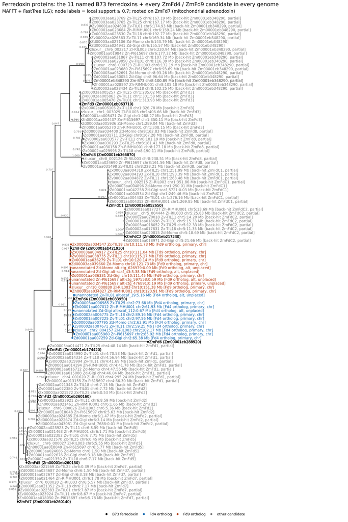

```r
tr <- read.tree(nwk); tr$tip.label <- tp$tip[as.integer(sub("^t", "", tr$tip.label))]
# the protein alignment behind the tree, with the tip labels as FASTA names (for an alignment viewer)
aa <- readAAStringSet(afa); names(aa) <- tp$tip[as.integer(sub("^t", "", names(aa)))]
writeXStringSet(aa, file.path(RES, "ferredoxin_tree.aln.faa"))
out_tip <- grep("^ZmFd7 ", tr$tip.label, value = TRUE)
if (length(out_tip)) tr <- root(tr, outgroup = out_tip, resolve.root = TRUE)
write.tree(tr, nwk)
ggtree(tr) %<+% (tp %>% transmute(label = tip, group, b73)) + geom_tippoint(aes(colour = group), size = 1.6) +
  geom_tiplab(aes(colour = group, fontface = ifelse(b73, "bold", "plain")), size = 3.15, offset = 0.01, show.legend = FALSE) +   # 2.8 mm + 1 pt
  geom_nodelab(aes(label = ifelse(!is.na(suppressWarnings(as.numeric(label))) & as.numeric(label) >= 0.7, label, "")),
               size = 2.2, hjust = 1.3, vjust = -0.4, colour = "grey40") +
  scale_colour_manual(values = c("B73 ferredoxin" = "black", "Fd4 ortholog" = "#1F6FB4", "Fd9 ortholog" = "#B4451F",
                                 "other candidate" = "grey50"), name = NULL) +
  xlim(0, max(node.depth.edgelength(tr)) * 2.4) + theme(legend.position = "bottom") +
  labs(title = "Ferredoxin proteins: the 11 named B73 ferredoxins + every ZmFd4 / ZmFd9 candidate in every genome",
       subtitle = "MAFFT + FastTree (LG); node labels = local support ≥ 0.7; rooted on ZmFd7 (mitochondrial adrenodoxin)")
```

```r
ggsave(file.path(RES, "ferredoxin_tree.png"), width = 12, height = 18, dpi = 150)
```

## 4. Loci in gene orientation

Each locus runs from 6000 bp upstream of the ATG to 1000 bp past the CDS end, reverse complemented for minus-strand genes, so position 6001 is the A of the ATG in every locus. Gene-model features are projected onto the same coordinates.

```r
missing <- ACC %>% select(genome = accession) %>% crossing(gene = GENES$gene) %>% anti_join(orth %>% filter(hap == "primary"), by = c("genome", "gene"))
if (nrow(missing)) stop("no primary ortholog for: ", paste(missing$genome, missing$gene, collapse = "; "))
orth <- orth %>% mutate(
  from = ifelse(strand == "+", atg - UP, cds_end - DOWN),
  to   = ifelse(strand == "+", cds_end + DOWN, atg + UP))
to_locus <- function(g, o) if (o$strand == "+") g - o$from + 1L else o$to - g + 1L
loc_to_g <- function(p, o) if (o$strand == "+") o$from - 1L + p else o$to + 1L - p
b4 <- orth %>% filter(genome == "B73", gene == "ZmFd4", hap == "primary")
INDEL194_G <- list(chr = b4$chr, range = sort(c(loc_to_g(INDEL194_LOC[1], b4), loc_to_g(INDEL194_LOC[2], b4))))
cat(sprintf("InDel194 (Jia 2025) in B73 v5: %s:%s-%s (%d bp)\n", INDEL194_G$chr, format(INDEL194_G$range[1], big.mark = ","),
            format(INDEL194_G$range[2], big.mark = ","), diff(INDEL194_G$range) + 1L))
```

```
InDel194 (Jia 2025) in B73 v5: chr2:59,575,138-59,575,741 (604 bp)
```

```r
# A locus can run past the end of its contig (e.g. a short alt scaffold): extract the part that exists and pad the
# missing end with N, so the A of the ATG stays at position UP + 1 in every locus. N columns are never primer sites.
seq_len_of <- function(genome, chr) { f <- read_tsv(ACC$fai[ACC$accession == genome], col_names = c("chr", "len"),
                                                    col_types = "ci___", show_col_types = FALSE); f$len[f$chr == chr] }
orth <- orth %>% rowwise() %>% mutate(chr_len = seq_len_of(genome, chr)) %>% ungroup() %>%
  mutate(pad_lo = pmax(0L, 1L - from), pad_hi = pmax(0L, to - chr_len),
         pad5 = ifelse(strand == "+", pad_lo, pad_hi), pad3 = ifelse(strand == "+", pad_hi, pad_lo))
if (any(orth$pad5 + orth$pad3 > 0))
  message("loci padded with N at a contig end: ", paste(with(filter(orth, pad5 + pad3 > 0), sprintf("%s %s (5' %d, 3' %d bp)", accession, gene, pad5, pad3)), collapse = "; "))
loci <- map(set_names(GENES$gene), function(g) {
  oo <- orth %>% filter(gene == g)
  s <- DNAStringSet(map(seq_len(nrow(oo)), function(k) {
    core <- grab(oo$genome[k], oo$chr[k], max(1L, oo$from[k]), min(oo$chr_len[k], oo$to[k]), oo$strand[k] == "-")
    xscat(DNAString(strrep("N", oo$pad5[k])), core, DNAString(strrep("N", oo$pad3[k])))
  }))
  names(s) <- oo$accession
  writeXStringSet(s, file.path(WORK, "loci", paste0(g, ".fa")))
  s
})
feats <- models %>% left_join(orth %>% select(accession, gene, strand, from, to), by = c("accession", "gene")) %>%
  rowwise() %>% mutate(s = to_locus(start, list(strand = strand.y, from = from, to = to)),
                       e = to_locus(end,   list(strand = strand.y, from = from, to = to))) %>% ungroup() %>%
  transmute(gene, accession, type, start = pmin(s, e), end = pmax(s, e)) %>% arrange(gene, accession, start)
# first CDS exon of each locus (transcript order = locus order after orientation)
cds1 <- feats %>% filter(type == "CDS") %>% group_by(gene, accession) %>% slice_min(start, n = 1) %>% ungroup()
knitr::kable(feats %>% filter(type == "exon") %>% group_by(gene, accession) %>%
               summarise(exons = paste(sprintf("%d-%d", start - UP - 1L, end - UP - 1L), collapse = ", "), .groups = "drop"),
             caption = "Exons relative to the ATG (A = 0). The 5′UTR exon and intron lie upstream of the ATG.")
```

Exons relative to the ATG (A = 0). The 5′UTR exon and intron lie upstream of the ATG.

| gene | accession | exons |
| --- | --- | --- |
| ZmFd4 | B73 | -2071–1891, -17-644 |
| ZmFd4 | Gigi | -2072–1919, -17-713 |
| ZmFd4 | Momo | -1964–1751, -17-686 |
| ZmFd4 | PI615697 | -2175–1987, -17-830 |
| ZmFd4 | RIL003 | -2639–2449, -17-812 |
| ZmFd4 | RIMHU001 | -1867–1714, -17-874 |
| ZmFd4 | TIL01 | -1485–1298, -17-744 |
| ZmFd4 | TIL11 | -2056–1874, -17-795 |
| ZmFd4 | TIL18 | -1467–1286, -17-823 |
| ZmFd4 | TIL25 | -1468–1305, -17-726 |
| ZmFd9 | B73 | -2693–2617, -23-444 |
| ZmFd9 | Gigi | -2601–2320, -17-1166 |
| ZmFd9 | Momo | -2564–2245, -17-1169 |
| ZmFd9 | RIL003 | -2633–2392, -2214–2212, -2056–1998, -17-1012 |
| ZmFd9 | RIMHU001 | -2809–2706, -17-663 |
| ZmFd9 | TIL01 | -2547–2292, -23-730, 800-1225 |
| ZmFd9 | TIL11 | -2701–2378, -17-641 |
| ZmFd9 | TIL18 | -2604–2288, -17-698, 768-1190 |
| ZmFd9 | TIL25 | -2466–2297, -17-1067 |

## 5. Alignment and conserved columns

MAFFT E-INS-i (`--genafpair`, suited to long unalignable stretches such as indels/TEs) per gene. Conservation is evaluated on **B73 coordinates** of the alignment:

- **invariant** = every accession has the B73 base, no gap, and no insertion in any accession between this base and the next (an insertion would break a primer’s contiguous match);
- **SNP** = all accessions have a base (no gap/insertion) but not the same one — allowed only in pass 2.

```r
aln <- map(set_names(GENES$gene), function(g) {
  af <- file.path(WORK, "aln", paste0(g, ".aln.fa"))
  lf <- file.path(WORK, "loci", paste0(g, ".fa"))
  if (!file.exists(af) || file.mtime(af) < file.mtime(lf)) sh(sprintf("mafft --genafpair --maxiterate 1000 --thread %d --quiet %s > %s",
                                   THREADS, shQuote(file.path(WORK, "loci", paste0(g, ".fa"))), shQuote(af)))
  m <- as.matrix(readDNAMultipleAlignment(af))
  m[c("B73", setdiff(rownames(m), "B73")), , drop = FALSE]
})

cons <- imap(aln, function(m, g) {
  cols <- which(m["B73", ] != "-"); n <- length(cols)
  col_ok <- function(cc) { x <- m[, cc]; c(all(x != "-" & x != "N"), length(unique(x)) == 1L) }
  st <- vapply(cols, col_ok, logical(2))
  ins_after <- vapply(seq_len(n), function(i) {
    if (i == n) return(FALSE); between <- seq_len(cols[i + 1] - cols[i] - 1) + cols[i]
    length(between) > 0 && any(m[, between, drop = FALSE] != "-") }, logical(1))
  brk <- ins_after | c(FALSE, ins_after[-n])
  # per-column entropy over bases only (gaps tracked separately so a large indel is not "entropy")
  ent <- vapply(cols, function(cc) { x <- m[, cc]; x <- x[x %in% c("A","C","G","T")]
    if (!length(x)) return(NA_real_); p <- table(x) / length(x); -sum(p * log2(p)) }, numeric(1))
  gapf <- vapply(cols, function(cc) mean(m[, cc] == "-"), numeric(1))
  tibble(gene = g, pos = seq_len(n), b73 = m["B73", cols],
         status = case_when(!st[1, ] | brk ~ "gap", st[2, ] ~ "invariant", TRUE ~ "snp"),
         entropy = ent, gap_frac = gapf, col = cols)
})
cons_all <- bind_rows(cons)
knitr::kable(cons_all %>% count(gene, status) %>% pivot_wider(names_from = status, values_from = n),
             caption = "B73 positions of each locus by cross-accession status.")
```

B73 positions of each locus by cross-accession status.

| gene | gap | invariant | snp |
| --- | --- | --- | --- |
| ZmFd4 | 4249 | 2247 | 972 |
| ZmFd9 | 5024 | 1994 | 426 |

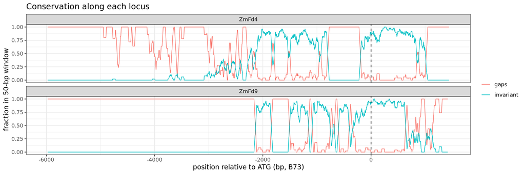

```r
cons_all %>% mutate(x = pos - UP - 1L) %>% group_by(gene) %>%
  mutate(invariant = stats::filter(status == "invariant", rep(1/50, 50), sides = 2),
         gaps = stats::filter(status == "gap", rep(1/50, 50), sides = 2)) %>%
  select(gene, x, invariant, gaps) %>% pivot_longer(c(invariant, gaps)) %>%
  ggplot(aes(x, value, colour = name)) + geom_line(linewidth = 0.4) + facet_wrap(~gene, ncol = 1) +
  geom_vline(xintercept = 0, linetype = "dashed") +
  labs(x = "position relative to ATG (bp, B73)", y = "fraction in 50-bp window", colour = NULL,
       title = "Conservation along each locus") + theme_bw()
```

## 6. Primer3 on the conserved template

The B73 locus is the template, with every non-invariant position replaced by `N` and `PRIMER_MAX_NS_ACCEPTED=0`, so Primer3 can only place primers on sites identical in all accessions. `SEQUENCE_PRIMER_PAIR_OK_REGION_LIST` confines the forward primer to the region upstream of the ATG and the reverse primer to the first CDS exon.

```r
iupac <- c(A="A",C="C",G="G",T="T",AG="R",CT="Y",CG="S",AT="W",GT="K",AC="M",CGT="B",AGT="D",ACT="H",ACG="V",ACGT="N")
iupac_col <- function(x) iupac[[paste(sort(unique(x)), collapse = "")]]
fold_deg <- function(s) { k <- c(R=2,Y=2,S=2,W=2,K=2,M=2,B=3,D=3,H=3,V=3,N=4)[strsplit(s, "")[[1]]]; prod(k, na.rm = TRUE) }
deg_primer <- function(m, cols, rev) {
  s <- vapply(cols, function(cc) iupac_col(m[, cc]), "")
  s <- paste(s, collapse = ""); if (rev) as.character(reverseComplement(DNAString(s))) else s
}
run_p3 <- function(g, pass) {
  cs <- cons[[g]]; b <- cds1 %>% filter(gene == g, accession == "B73")
  keep <- if (pass == 1) cs$status == "invariant" else cs$status != "gap"
  tmpl <- paste(ifelse(keep, cs$b73, "N"), collapse = "")
  p3in <- file.path(WORK, "p3", sprintf("%s_pass%d.in", g, pass)); p3out <- sub("\\.in$", ".out", p3in)
  writeLines(c(sprintf("SEQUENCE_ID=%s_pass%d", g, pass), paste0("SEQUENCE_TEMPLATE=", tmpl),
    sprintf("SEQUENCE_PRIMER_PAIR_OK_REGION_LIST=0,%d,%d,%d", UP, b$start - 1L, b$end - b$start + 1L),
    "PRIMER_TASK=generic", "PRIMER_FIRST_BASE_INDEX=0", "PRIMER_PICK_INTERNAL_OLIGO=0",
    sprintf("PRIMER_PRODUCT_SIZE_RANGE=%d-%d", P3_RANGE[1], P3_RANGE[2]),
    "PRIMER_MIN_SIZE=19", "PRIMER_OPT_SIZE=22", "PRIMER_MAX_SIZE=27",
    "PRIMER_MIN_TM=57.0", "PRIMER_OPT_TM=60.0", "PRIMER_MAX_TM=63.0", "PRIMER_PAIR_MAX_DIFF_TM=3.0",
    "PRIMER_MIN_GC=40.0", "PRIMER_OPT_GC_PERCENT=50.0", "PRIMER_MAX_GC=60.0",
    "PRIMER_GC_CLAMP=1", "PRIMER_MAX_POLY_X=4", "PRIMER_MAX_NS_ACCEPTED=0",
    "PRIMER_EXPLAIN_FLAG=1", "PRIMER_NUM_RETURN=500", "="), p3in)
  sh(sprintf("primer3_core %s > %s", shQuote(p3in), shQuote(p3out)))
  L <- readLines(p3out); L <- L[grepl("=", L, fixed = TRUE) & L != "="]
  kv <- strsplit(L, "=", fixed = TRUE)
  d <- setNames(vapply(kv, function(x) paste(x[-1], collapse = "="), ""), vapply(kv, `[`, "", 1))
  np <- as.integer(d[["PRIMER_PAIR_NUM_RETURNED"]])
  if (np == 0) { message(g, " pass ", pass, ": ", d[["PRIMER_PAIR_EXPLAIN"]]); return(NULL) }
  m <- aln[[g]]
  map_dfr(0:(np - 1), function(i) {
    v <- function(k) d[[sprintf(k, i)]]
    lp <- as.integer(strsplit(v("PRIMER_LEFT_%d"), ",")[[1]]); rp <- as.integer(strsplit(v("PRIMER_RIGHT_%d"), ",")[[1]])
    f <- (lp[1] + 1L):(lp[1] + lp[2]); r <- (rp[1] - rp[2] + 2L):(rp[1] + 1L)     # 1-based B73 locus positions
    Fd <- deg_primer(m, cs$col[f], FALSE); Rd <- deg_primer(m, cs$col[r], TRUE)
    tibble(gene = g, pass = pass, rank = i, penalty = round(as.numeric(v("PRIMER_PAIR_%d_PENALTY")), 3),
      prod_b73 = as.integer(v("PRIMER_PAIR_%d_PRODUCT_SIZE")),
      F_seq = Fd, R_seq = Rd, F_len = lp[2], R_len = rp[2],
      F_tm = round(as.numeric(v("PRIMER_LEFT_%d_TM")), 1), R_tm = round(as.numeric(v("PRIMER_RIGHT_%d_TM")), 1),
      F_gc = round(as.numeric(v("PRIMER_LEFT_%d_GC_PERCENT")), 1), R_gc = round(as.numeric(v("PRIMER_RIGHT_%d_GC_PERCENT")), 1),
      F_from_atg = min(f) - UP - 1L, R_from_atg = max(r) - UP - 1L,
      deg = str_count(paste0(Fd, Rd), "[^ACGT]"),
      fold = fold_deg(paste0(Fd, Rd)),
      end3_ok = !grepl("[^ACGT]", str_sub(Fd, -5)) & !grepl("[^ACGT]", str_sub(Rd, -5)))
  })
}
pairs <- map_dfr(GENES$gene, function(g) {
  p <- run_p3(g, 1)
  if (is.null(p)) p <- run_p3(g, 2) %>% filter(end3_ok, deg <= 4, fold <= 16)
  p
})
stopifnot(nrow(pairs) > 0)
```

## 7. Every primer must bind every accession

Each primer (degenerate primers as IUPAC patterns) is matched exactly against each accession’s locus; the product size per accession follows from the two sites.

```r
bind_check <- pairs %>% rowwise() %>% mutate(chk = list(map_dfr(names(loci[[gene]]), function(a) {
  s <- loci[[gene]][[a]]
  fh <- start(matchPattern(DNAString(F_seq), s, fixed = "subject"))
  rh <- end(matchPattern(reverseComplement(DNAString(R_seq)), s, fixed = "subject"))
  tibble(accession = a, F_sites = length(fh), R_sites = length(rh),
         product = if (length(fh) == 1 && length(rh) == 1) rh - fh + 1L else NA_integer_)
}))) %>% ungroup() %>%
  mutate(all_bind = map_lgl(chk, ~ all(.x$F_sites == 1 & .x$R_sites == 1)),
         min_prod = map_int(chk, ~ suppressWarnings(min(.x$product))),
         max_prod = map_int(chk, ~ suppressWarnings(max(.x$product))))
# cap in every accession; rank by product in the shortest accession (50-bp bins), then penalty;
# greedy pick of pairs whose F and R sites are both >= MIN_SEP from every pair already chosen
pick <- function(d) {
  d <- d %>% arrange(desc(min_prod %/% 50L), penalty); keep <- integer(0)
  for (i in seq_len(nrow(d))) {
    far <- all(abs(d$F_from_atg[i] - d$F_from_atg[keep]) >= MIN_SEP & abs(d$R_from_atg[i] - d$R_from_atg[keep]) >= MIN_SEP)
    if (far) keep <- c(keep, i); if (length(keep) == N_PAIRS) break }
  d[keep, ]
}
cand <- bind_check %>% filter(all_bind, max_prod <= PRODUCT_MAX) %>% group_by(gene) %>% group_modify(~ pick(.x)) %>%
  mutate(name = sprintf("%s-P%d", gene, row_number())) %>% ungroup()
knitr::kable(bind_check %>% count(gene, all_bind), caption = "Primer3 pairs whose both primers bind once in every accession.")
```

Primer3 pairs whose both primers bind once in every accession.

| gene | all_bind | n |
| --- | --- | --- |
| ZmFd4 | TRUE | 500 |
| ZmFd9 | TRUE | 143 |

## 8. Whole-genome e-PCR specificity

`-n 3 -g 1`: up to 3 mismatches and 1 gap per primer (as in `primermu`). Each product is placed: **own locus** (primary haplotype), **alt haplotype** (the same gene on an `alt-*` scaffold — expected, a teosinte plant carries both), **PARALOG** (the other ferredoxin) or **elsewhere**. As in `primermu`, each primer site of an unexpected product is re-read from the genome: a product counts as a real off-target only if **neither primer has a mismatch in its 3′-most 5 nt** (a 3′ mismatch blocks extension).

```r
jia <- read_tsv("config/jia2025_primers.tsv", show_col_types = FALSE)
jia_pairs <- tibble(name = c("Jia-G1 (G-F1/G-R1)", "Jia-G2 (G-F2/G-R2)", "Jia-Fd9-JD"), gene = c("ZmFd4", "ZmFd4", "ZmFd9"),
                    F_seq = jia$seq[match(c("ZmFd4-G-F1", "ZmFd4-G-F2", "ZmFd9-JD-F"), jia$name)],
                    R_seq = jia$seq[match(c("ZmFd4-G-R1", "ZmFd4-G-R2", "ZmFd9-JD-R"), jia$name)])
sts_tbl <- bind_rows(cand %>% select(name, gene, F_seq, R_seq), jia_pairs) %>% mutate(sts = str_replace_all(name, "[ ()/]", "_"))
sts <- file.path(WORK, "epcr", "pairs.sts")
writeLines(sprintf("%s\t%s\t%s\t100-5000", sts_tbl$sts, sts_tbl$F_seq, sts_tbl$R_seq), sts)
ep <- map_dfr(seq_len(nrow(ACC)), function(i) {
  o <- file.path(WORK, "epcr", paste0(ACC$accession[i], ".txt"))
  if (!file.exists(o) || file.mtime(o) < file.mtime(sts))
    sh(sprintf("e-PCR -n 3 -g 1 -m 50 -w 7 -t 3 -a f -o %s %s %s", shQuote(o), shQuote(sts), shQuote(ACC$fa[i])))
  if (!file.info(o)$size) return(NULL)
  read_tsv(o, comment = "#", show_col_types = FALSE, col_types = "ccciiciic",
           col_names = c("seq","sts","strand","from","to","size","mism","gaps","x")) %>% mutate(genome = ACC$accession[i])
}) %>% left_join(sts_tbl %>% select(sts, name, pair_gene = gene, F_seq, R_seq), by = "sts")

# place each product
ep <- ep %>% rowwise() %>% mutate(hit_at = {
  o <- orth %>% filter(genome == .env$genome, chr == seq, from <= .env$to, to >= .env$from)
  if (!nrow(o)) "elsewhere" else if (o$gene[1] != pair_gene) "PARALOG" else if (o$hap[1] == "alt") "alt haplotype" else "own locus"
}) %>% ungroup()

# Mismatches of each primer at its site, IUPAC-aware and gap-aware (e-PCR -g 1 allows one gap per primer, so an
# ungapped comparison misreads every base after the gap). Each primer is aligned (edit distance) to a window that
# starts at its 5' end on the outer edge of the product and is G bases longer than the primer; mismatches and gaps
# are counted overall and within the 3'-most 5 nt (a gap between two bases is assigned to the 3'-side base).
iupac_set <- list(A="A",C="C",G="G",T="T",R="AG",Y="CT",S="CG",W="AT",K="GT",M="AC",B="CGT",D="AGT",H="ACT",V="ACG",N="ACGT")
G_SLACK <- 3L
align_primer <- function(site, p) {
  a <- strsplit(site, "")[[1]]; b <- strsplit(p, "")[[1]]; n <- length(b); m <- length(a)
  mis <- function(i, j) !grepl(a[j], iupac_set[[b[i]]], fixed = TRUE)
  D <- matrix(Inf, n + 1, m + 1); D[1, ] <- 0:m; D[, 1] <- 0:n
  for (i in 1:n) for (j in 1:m) D[i + 1, j + 1] <- min(D[i, j] + mis(i, j), D[i, j + 1] + 1, D[i + 1, j] + 1)
  i <- n + 1; j <- which.min(D[n + 1, ]); total <- D[i, j]; ev <- integer(0)
  while (i > 1) {
    if (j > 1 && D[i, j] == D[i - 1, j - 1] + mis(i - 1, j - 1)) { if (mis(i - 1, j - 1)) ev <- c(ev, i - 1); i <- i - 1; j <- j - 1 }
    else if (D[i, j] == D[i - 1, j] + 1) { ev <- c(ev, i - 1); i <- i - 1 }   # primer base unpaired
    else { ev <- c(ev, i); j <- j - 1 }                                          # extra genome base before primer base i
  }
  c(total = total, end3 = sum(ev > n - 5))
}
ep <- ep %>% rowwise() %>% mutate(m = list({
  lf <- nchar(F_seq) + G_SLACK; lr <- nchar(R_seq) + G_SLACK; TO <- to + 1L
  # windows start at each primer's 5' end (outer product edge), in primer orientation
  if (strand == "+") { fw <- grab(genome, seq, from, from + lf - 1L);     rw <- grab(genome, seq, TO - lr + 1L, TO, TRUE) }
  else               { fw <- grab(genome, seq, TO - lf + 1L, TO, TRUE);  rw <- grab(genome, seq, from, from + lr - 1L) }
  cf <- align_primer(as.character(fw), F_seq); cr <- align_primer(as.character(rw), R_seq)
  tibble(F_mm = cf[["total"]], F_3p = cf[["end3"]], R_mm = cr[["total"]], R_3p = cr[["end3"]])
})) %>% ungroup() %>% unnest(m) %>%
  mutate(amp_bp = to - from + 2L, real_off = hit_at %in% c("elsewhere", "PARALOG") & F_3p == 0 & R_3p == 0)
write_tsv(ep %>% select(name, genome, seq, strand, from, to, amp_bp, hit_at, F_mm, F_3p, R_mm, R_3p, real_off),
          file.path(RES, "epcr_hits.tsv"))

spec <- ep %>% group_by(name, genome) %>%
  summarise(own = sum(hit_at == "own locus"), alt = sum(hit_at == "alt haplotype"),
            off_3p_mismatch = sum(hit_at %in% c("elsewhere", "PARALOG") & !real_off), off_real = sum(real_off), .groups = "drop") %>%
  complete(name = sts_tbl$name, genome = ACC$accession, fill = list(own = 0L, alt = 0L, off_3p_mismatch = 0L, off_real = 0L))
knitr::kable(spec %>% mutate(cell = sprintf("%d%s%s", own, ifelse(alt > 0, sprintf("+%da", alt), ""),
                                            ifelse(off_real > 0, sprintf(" OFF%d", off_real), ""))) %>%
               select(name, genome, cell) %>% pivot_wider(names_from = genome, values_from = cell),
             caption = "Products per pair and genome: own-locus count, +Na = alt haplotype, OFFn = real off-targets (3′ ends match).")
```

Products per pair and genome: own-locus count, +Na = alt haplotype, OFFn = real off-targets (3′ ends match).

| name | B73 | Gigi | Momo | PI615697 | RIL003 | RIMHU001 | TIL01 | TIL11 | TIL18 | TIL25 |
| --- | --- | --- | --- | --- | --- | --- | --- | --- | --- | --- |
| Jia-Fd9-JD | 1 | 1+1a | 0+1a | 1 OFF1 | 0 OFF1 | 1 | 0 | 1 | 0 OFF1 | 1 |
| Jia-G1 (G-F1/G-R1) | 1 | 1+1a | 1 | 1 | 1 | 1 | 1+1a | 1 | 1 | 1 |
| Jia-G2 (G-F2/G-R2) | 1 OFF1 | 1+1a | 1 OFF1 | 1 | 1 OFF1 | 0 | 1+1a OFF1 | 1 | 1 | 1 |
| ZmFd4-P1 | 1 | 1+1a | 1 | 1 | 1 | 1 | 1+1a | 1 | 1 | 1 |
| ZmFd4-P2 | 1 | 1+1a | 1 | 1 | 1 | 1 | 1+1a | 1 | 1 | 1 |
| ZmFd9-P1 | 1 | 1+1a | 1+1a | 1+1a | 1 | 1 | 1 | 1 | 1 | 1 |

## 9. Recommended pairs

```r
specific <- spec %>% group_by(name) %>%
  summarise(specific = all(own == 1 & off_real == 0), weak_off = sum(off_3p_mismatch), .groups = "drop")
final <- cand %>% left_join(specific, by = "name") %>% filter(specific %in% TRUE)
write_tsv(final %>% select(name, gene, pass, F_seq, R_seq, F_len, R_len, F_tm, R_tm, F_gc, R_gc,
                           F_from_atg, R_from_atg, prod_b73, min_prod, max_prod, deg, penalty, weak_off),
          file.path(RES, "primers.tsv"))
knitr::kable(final %>% transmute(name, forward = F_seq, reverse = R_seq, `F Tm` = F_tm, `R Tm` = R_tm,
                                 `F 5′ vs ATG` = F_from_atg, `R 3′ end vs ATG` = R_from_atg,
                                 `B73 bp` = prod_b73, `range across loci` = sprintf("%d–%d", min_prod, max_prod),
                                 degenerate = deg, `off-targets with 3′ mismatch` = weak_off, penalty),
             caption = "Pairs that bind every locus (both haplotypes) once and give no real off-target product in any genome.")
```

Pairs that bind every locus (both haplotypes) once and give no real off-target product in any genome.

| name | forward | reverse | F Tm | R Tm | F 5′ vs ATG | R 3′ end vs ATG | B73 bp | range across loci | degenerate | off-targets with 3′ mismatch | penalty |
| --- | --- | --- | --- | --- | --- | --- | --- | --- | --- | --- | --- |
| ZmFd4-P1 | CGCTTCAATTTCCACCCTAATCC | CAGGAGTAGGGCAGGTCTATAC | 59.9 | 58.8 | -2032 | 292 | 2325 | 1720–2877 | 0 | 0 | 2.225 |
| ZmFd4-P2 | GTGTTTCTGAATGCGTGTGC | CTGTCCTCTGGCACTTGGATC | 58.6 | 60.4 | -1664 | 241 | 1906 | 1301–2279 | 0 | 3 | 4.805 |
| ZmFd9-P1 | TGCAATCATGTCCTGCTTCATAG | AGGAACGACTGGTCTGCCTG | 59.1 | 61.8 | -1447 | 358 | 1806 | 1706–2193 | 0 | 0 | 5.702 |

```r
if (!nrow(final)) message("No pair passed: see the e-PCR table above.")
```

## 9b. Annotation maps of the products

One figure per recommended pair, one track per whole-genome e-PCR product (own locus, second `alt` haplotype, and any off-locus product), as in the `primermu` / `primercrisp` annotation maps. Window = product ± 150 bp; minus-strand products are flipped so the forward primer is always leftmost (primer orientation, not genome orientation). Tracks, bottom to top:

- **homology** to the other products (computed: each window is blastn’d against the others, `-word_size 9`, no dust; overlapping HSPs merged, blocks ≥ 40 bp drawn) — a gap shows sequence the others lack, e.g. InDel194 present only in B73;
- **transposable elements** (MaizeGDB EDTA annotation, labelled by class; none for RIL003);
- **exons** of any gene overlapping the window (gene model ID);
- the **primer sites** (arrows, labelled with mismatches) and the **product** (green = expected, red = off-target with matching 3′ ends, grey = off-target with a 3′ mismatch).

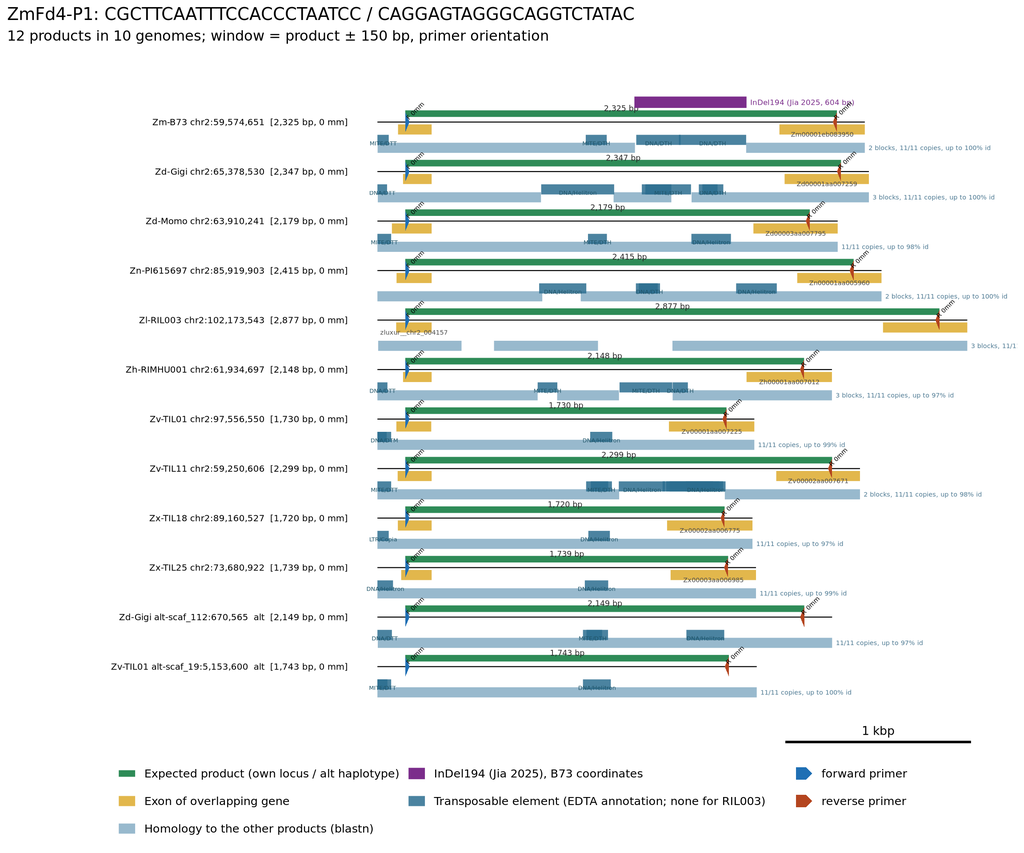

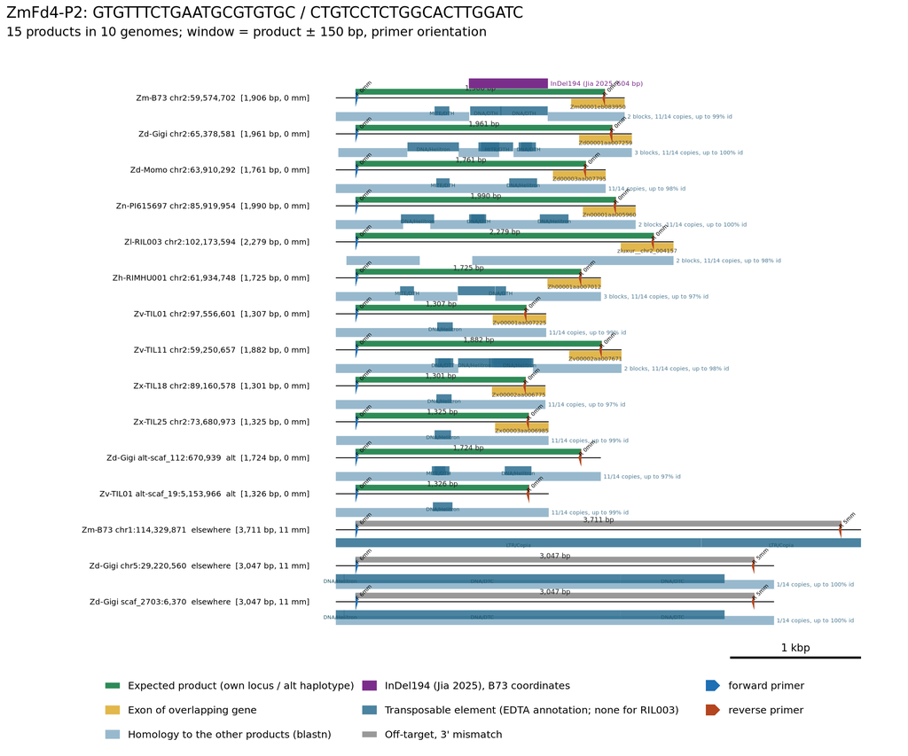

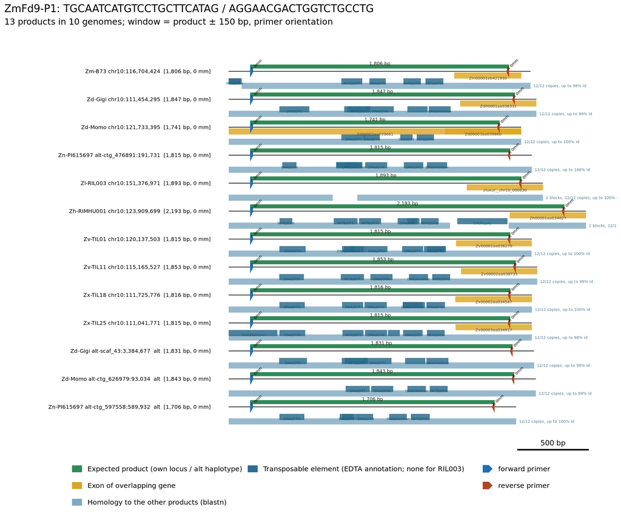

```r
PADP <- 150L
empty_feat <- tibble(seq_id = character(), start = integer(), end = integer(), feat_type = character(), name = character())
merge_iv <- function(d) {                                   # merge overlapping/abutting HSPs on the query
  d <- d %>% arrange(qstart); out <- list(); cur <- NULL
  for (k in seq_len(nrow(d))) {
    if (is.null(cur)) cur <- list(s = d$qstart[k], e = d$qend[k], p = d$pident[k], subj = d$s[k])
    else if (d$qstart[k] <= cur$e + 1L) { cur$e <- max(cur$e, d$qend[k]); cur$p <- c(cur$p, d$pident[k]); cur$subj <- c(cur$subj, d$s[k]) }
    else { out[[length(out) + 1L]] <- cur; cur <- list(s = d$qstart[k], e = d$qend[k], p = d$pident[k], subj = d$s[k]) }
  }
  if (!is.null(cur)) out[[length(out) + 1L]] <- cur
  bind_rows(lapply(out, function(z) tibble(start = z$s, end = z$e, n_copies = n_distinct(z$subj), pmax = max(z$p))))
}
MIN_HOM <- 40L
annotation_map <- function(pr) {
  pan <- ep %>% filter(name == pr$name) %>%
    mutate(TO = to + 1L, lf = nchar(F_seq), lr = nchar(R_seq),
           o = case_when(genome == "B73" & hit_at == "own locus" ~ 0, hit_at == "own locus" ~ 1, hit_at == "alt haplotype" ~ 2, TRUE ~ 3)) %>%
    arrange(o, genome) %>% rowwise() %>%
    mutate(chr_len = seq_len_of(genome, seq), win_start = max(1L, from - PADP), win_end = min(chr_len, TO + PADP),
           F_s = ifelse(strand == "+", from, TO - lf + 1L), F_e = ifelse(strand == "+", from + lf - 1L, TO),
           R_s = ifelse(strand == "+", TO - lr + 1L, from), R_e = ifelse(strand == "+", TO, from + lr - 1L)) %>% ungroup() %>%
    mutate(id = sprintf("p%02d", row_number()),
           tag = case_when(hit_at == "own locus" ~ "", hit_at == "alt haplotype" ~ "  alt", TRUE ~ sprintf("  %s", tolower(hit_at))),
           panel = sprintf("%s %s:%s%s  [%s bp, %d mm]", taxon_prefix(genome), seq, format(from, big.mark = ",", trim = TRUE), tag,
                           format(amp_bp, big.mark = ",", trim = TRUE), F_mm + R_mm),
           panel = factor(panel, levels = rev(unique(panel))))
  tl  <- function(g, i) if (pan$strand[i] == "+") as.integer(g - pan$win_start[i] + 1L) else as.integer(pan$win_end[i] - g + 1L)
  seg <- function(a, b, i) sort(c(tl(a, i), tl(b, i)))
  pseqs <- pan %>% transmute(seq_id = as.character(panel), length = win_end - win_start + 1L)
  pamp <- bind_rows(lapply(seq_len(nrow(pan)), function(i) { a <- seg(pan$from[i], pan$TO[i], i)
    tibble(seq_id = as.character(pan$panel[i]), start = a[1], end = a[2],
           feat_type = case_when(pan$hit_at[i] %in% c("own locus", "alt haplotype") ~ "amplicon", pan$real_off[i] ~ "off_target", TRUE ~ "weak_off"),
           name = sprintf("%s bp", format(pan$amp_bp[i], big.mark = ","))) }))
  pprim <- bind_rows(lapply(seq_len(nrow(pan)), function(i) { f <- seg(pan$F_s[i], pan$F_e[i], i); r <- seg(pan$R_s[i], pan$R_e[i], i)
    tibble(seq_id = as.character(pan$panel[i]), start = c(f[1], r[2]), end = c(f[2], r[1]),          # drawn 5'->3'
           feat_type = c("forward_primer", "reverse_primer"), name = sprintf(c("F %dmm", "R %dmm"), c(pan$F_mm[i], pan$R_mm[i]))) }))
  pex <- bind_rows(lapply(seq_len(nrow(pan)), function(i) {
    ex <- read_gff(ACC$gff[ACC$accession == pan$genome[i]],
                   sprintf("$3==\"exon\" && $1==\"%s\" && $5>=%d && $4<=%d", pan$seq[i], pan$win_start[i], pan$win_end[i]))
    if (is.null(ex)) return(NULL)
    bind_rows(lapply(seq_len(nrow(ex)), function(k) { x <- seg(max(ex$start[k], pan$win_start[i]), min(ex$end[k], pan$win_end[i]), i)
      tibble(seq_id = as.character(pan$panel[i]), start = x[1], end = x[2], feat_type = "Exon", name = gene_of(tx_of(sub("_T\\d+$", "", ex$Parent[k])))) }))
  }))
  # homology: windows in panel orientation, so blastn query coordinates are already panel coordinates
  win_fa <- file.path(WORK, sprintf("annotation_windows_%s.fa", pr$name))
  writeXStringSet(DNAStringSet(setNames(map(seq_len(nrow(pan)), ~ grab(pan$genome[.x], pan$seq[.x], pan$win_start[.x], pan$win_end[.x], pan$strand[.x] == "-")), pan$id)), win_fa)
  hom <- bl6(sprintf("blastn -task blastn -query %s -subject %s -evalue 1e-5 -word_size 9 -dust no -outfmt '6 qseqid sseqid pident qstart qend'",
                     shQuote(win_fa), shQuote(win_fa)), c("q", "s", "pident", "qstart", "qend"))
  hom <- if (is.null(hom)) NULL else filter(hom, q != s)
  phom <- bind_rows(lapply(seq_len(nrow(pan)), function(i) {
    h <- if (is.null(hom)) NULL else hom %>% filter(q == pan$id[i]); if (is.null(h) || !nrow(h)) return(NULL)
    m <- merge_iv(h) %>% filter(end - start + 1L >= MIN_HOM); if (!nrow(m)) return(NULL)
    m %>% transmute(seq_id = as.character(pan$panel[i]), start, end, feat_type = "homology", n_copies, pmax,
                    name = sprintf("%d/%d copies, up to %.0f%% id", n_copies, nrow(pan) - 1L, pmax)) }))
  phom_lab <- if (!nrow(phom)) tibble(seq_id = character(), x = integer(), label = character()) else
    phom %>% group_by(seq_id) %>% summarise(x = max(end), nblk = n(), copies = max(n_copies), best = max(pmax), .groups = "drop") %>%
    mutate(label = ifelse(nblk == 1L, sprintf("%d/%d copies, up to %.0f%% id", copies, nrow(pan) - 1L, best),
                          sprintf("%d blocks, %d/%d copies, up to %.0f%% id", nblk, copies, nrow(pan) - 1L, best)))
  pte <- bind_rows(lapply(seq_len(nrow(pan)), function(i) {
    te <- read_te(pan$genome[i], pan$seq[i], pan$win_start[i], pan$win_end[i]); if (is.null(te) || !nrow(te)) return(NULL)
    bind_rows(lapply(seq_len(nrow(te)), function(k) { x <- seg(max(te$start[k], pan$win_start[i]), min(te$end[k], pan$win_end[i]), i)
      tibble(seq_id = as.character(pan$panel[i]), start = x[1], end = x[2], feat_type = "TE", name = te$Classification[k]) }))
  }))
  pind <- bind_rows(lapply(seq_len(nrow(pan)), function(i) {          # documented InDel194, B73 panel(s) only
    r <- INDEL194_G$range
    if (pan$genome[i] != "B73" || pan$seq[i] != INDEL194_G$chr || r[2] < pan$win_start[i] || r[1] > pan$win_end[i]) return(NULL)
    x <- seg(max(r[1], pan$win_start[i]), min(r[2], pan$win_end[i]), i)
    tibble(seq_id = as.character(pan$panel[i]), start = x[1], end = x[2], feat_type = "indel", name = "InDel194 (Jia 2025, 604 bp)")
  }))
  if (!nrow(pex)) pex <- empty_feat
  if (!nrow(phom)) phom <- empty_feat
  if (!nrow(pind)) pind <- empty_feat
  if (!nrow(pte)) pte <- empty_feat
  gg <- gggenomes(seqs = pseqs, genes = pprim, feats = list(amplicons = pamp, exons = pex, homology = phom, indel = pind, tes = pte))
  ymap <- pull_seqs(gg$data) %>% ungroup() %>% select(seq_id, y)
  gg + geom_seq() + geom_bin_label(size = 2.6, expand_left = 0.55) +
    geom_feat(data = feats(homology), aes(y = y - 0.52, yend = y - 0.52, color = feat_type), position = "identity", linewidth = 4, alpha = 0.8) +
    geom_text(data = phom_lab %>% left_join(ymap, by = "seq_id"), aes(x = x + 20, y = y - 0.52, label = label),
              hjust = 0, size = 1.9, color = "#4E7A93", inherit.aes = FALSE) +
    geom_feat(data = feats(tes), aes(y = y - 0.36, yend = y - 0.36, color = feat_type), position = "identity", linewidth = 4, alpha = 0.85) +
    geom_text(data = pte %>% left_join(ymap, by = "seq_id"), aes(x = (start + end) / 2, y = y - 0.43, label = name),
              size = 1.7, color = "#1F5468", check_overlap = TRUE, inherit.aes = FALSE) +
    geom_feat(data = feats(exons), aes(y = y - 0.15, yend = y - 0.15, color = feat_type), position = "identity", linewidth = 4, alpha = 0.8) +
    geom_text(data = pex %>% distinct(seq_id, name, .keep_all = TRUE) %>% left_join(ymap, by = "seq_id"),
              aes(x = (start + end) / 2, y = y - 0.25, label = name), size = 1.9, color = "grey30", inherit.aes = FALSE) +
    geom_feat(data = feats(amplicons), aes(y = y + 0.17, yend = y + 0.17, color = feat_type), position = "identity", linewidth = 2.6) +
    geom_text(data = pamp %>% left_join(ymap, by = "seq_id"), aes(x = (start + end) / 2, y = y + 0.28, label = name),
              size = 2.3, color = "grey15", inherit.aes = FALSE) +
    geom_feat(data = feats(indel), aes(y = y + 0.40, yend = y + 0.40, color = feat_type), position = "identity", linewidth = 4.5) +
    geom_text(data = pind %>% left_join(ymap, by = "seq_id"), aes(x = end + 20, y = y + 0.40, label = name),
              hjust = 0, size = 2.2, color = "#7B2D8B", inherit.aes = FALSE) +
    geom_gene(aes(fill = feat_type), color = NA, size = 6) +
    geom_gene_label(aes(label = name), size = 1.9, nudge_y = 0.07) +
    scale_color_manual(name = NULL,
      values = c("homology" = "#7FA8C0", "Exon" = "#DAA520", "amplicon" = "#2E8B57", "off_target" = "#C0392B", "weak_off" = "grey60",
                 "indel" = "#7B2D8B", "TE" = "#2C6E8F"),
      labels = c("indel" = "InDel194 (Jia 2025), B73 coordinates", "TE" = "Transposable element (EDTA annotation; none for RIL003)", "homology" = "Homology to the other products (blastn)", "Exon" = "Exon of overlapping gene",
                 "amplicon" = "Expected product (own locus / alt haplotype)", "off_target" = "Off-target, 3' ends match",
                 "weak_off" = "Off-target, 3' mismatch")) +
    scale_fill_manual(name = NULL, values = c("forward_primer" = "#1F6FB4", "reverse_primer" = "#B4451F"),
                      labels = c("forward_primer" = "forward primer", "reverse_primer" = "reverse primer")) +
    guides(color = guide_legend(nrow = 3), fill = guide_legend(nrow = 2)) +
    coord_cartesian(ylim = c(0.30, nrow(pan) + 0.62)) +
    labs(title = sprintf("%s: %s / %s", pr$name, pr$F_seq, pr$R_seq),
         subtitle = sprintf("%d products in %d genomes; window = product ± %d bp, primer orientation", nrow(pan), n_distinct(pan$genome), PADP),
         x = "position within window (bp)") +
    theme(legend.position = "bottom", axis.text.y = element_blank(), axis.ticks.y = element_blank(),
          axis.title.y = element_blank(), panel.grid.minor = element_blank())
}
for (i in seq_len(nrow(final))) {
  n_tr <- sum(ep$name == final$name[i])
  p <- annotation_map(final[i, ])
  ggsave(file.path(RES, sprintf("annotation_map_%s.png", final$name[i])), p, width = 12, height = 2 + 0.7 * n_tr, dpi = 150)
  print(p)
}
```

## 10. Jia *et al.* 2025 primers as a benchmark

Jia’s primers mapped onto every locus (up to 3 mismatches). **InDel194 call:** B73 carries the full promoter (Hap1); InDel194 is the 604-bp block ending 194 bp upstream of the ATG (B73 positions −798…−195). Each locus is called from the alignment (§5) by the fraction of those B73 positions that are gapped: > 80 % = Hap2 (deletion), < 20 % = Hap1 (full), otherwise partial. Product length alone is not used: other insertions elsewhere in the product (e.g. in *Z. luxurians*) change it independently.

```r
jia_map <- jia %>% filter(gene %in% GENES$gene) %>% rowwise() %>% mutate(m = list(map_dfr(names(loci[[gene]]), function(a) {
  s <- loci[[gene]][[a]]; p <- DNAString(seq)
  hf <- matchPattern(p, s, max.mismatch = 3); hr <- matchPattern(reverseComplement(p), s, max.mismatch = 3)
  h <- c(start(hf), end(hr)); mm <- c(nmismatch(p, hf), nmismatch(reverseComplement(p), hr))
  tibble(accession = a, sites = length(h), pos = if (length(h)) h[which.min(mm)] - UP - 1L else NA_integer_,
         mism = if (length(h)) min(mm) else NA_integer_)
}))) %>% ungroup() %>% unnest(m)
knitr::kable(jia_map %>% transmute(name, accession, mism = ifelse(is.na(mism), "no site (>3 mm)", as.character(mism))) %>%
               pivot_wider(names_from = accession, values_from = mism),
             caption = "Mismatches of each Jia primer at its best site in each locus.")
```

Mismatches of each Jia primer at its best site in each locus.

| name | B73 | Gigi | Gigi_alt | Momo | PI615697 | RIL003 | RIMHU001 | TIL01 | TIL01_alt | TIL11 | TIL18 | TIL25 | Momo_alt | PI615697_alt |
| --- | --- | --- | --- | --- | --- | --- | --- | --- | --- | --- | --- | --- | --- | --- |
| ZmFd4-G-F1 | 0 | 2 | 0 | 1 | 0 | 1 | 2 | 3 | 1 | 0 | 0 | 0 | NA | NA |
| ZmFd4-G-R1 | 0 | 1 | 1 | 1 | 1 | 1 | 1 | 1 | 0 | 1 | 1 | 0 | NA | NA |
| ZmFd4-G-F2 | 0 | 0 | 1 | 2 | 2 | 1 | 1 | 0 | 0 | 1 | 1 | 0 | NA | NA |
| ZmFd4-G-R2 | 0 | 1 | 0 | 1 | 0 | 0 | no site (>3 mm) | 0 | 2 | 0 | 0 | 0 | NA | NA |
| ZmFd4-JD-F | 0 | 0 | 0 | 0 | 0 | 0 | 0 | 0 | 0 | 2 | 0 | 0 | NA | NA |
| ZmFd4-JD-R | 0 | 1 | 0 | 1 | 0 | 0 | 0 | 0 | 0 | 0 | 0 | 0 | NA | NA |
| ZmFd4-S-JD-R | 0 | 0 | 0 | 0 | 1 | 1 | 1 | 0 | 1 | 1 | 0 | 1 | NA | NA |
| ZmFd4-NIL-F | 0 | 0 | no site (>3 mm) | no site (>3 mm) | no site (>3 mm) | no site (>3 mm) | no site (>3 mm) | no site (>3 mm) | 0 | no site (>3 mm) | no site (>3 mm) | 0 | NA | NA |
| ZmFd4-NIL-R | 0 | 0 | 0 | 1 | 0 | 0 | 0 | 0 | 0 | 0 | 0 | 0 | NA | NA |
| ZmFd9-JD-F | 0 | 1 | 1 | no site (>3 mm) | 2 | no site (>3 mm) | 3 | 0 | NA | 0 | 1 | 0 | 1 | no site (>3 mm) |
| ZmFd9-JD-R | 0 | 3 | 2 | 1 | 2 | 2 | 2 | no site (>3 mm) | NA | 2 | 2 | 2 | 3 | 2 |
| ZmFd9-S-JD-F | 0 | 1 | 1 | 0 | 1 | 1 | 2 | 0 | NA | 0 | 0 | 0 | 1 | 1 |
| ZmFd9-S-JD-R | 0 | 0 | 0 | 0 | 0 | 0 | 0 | 0 | NA | 0 | 0 | 2 | 0 | 0 |

```r
g1 <- jia_map %>% filter(name %in% c("ZmFd4-G-F1", "ZmFd4-G-R1")) %>% select(name, accession, pos) %>%
  pivot_wider(names_from = name, values_from = pos) %>% mutate(G1_bp = `ZmFd4-G-R1` - `ZmFd4-G-F1` + 1L)
indel_pos <- INDEL194_LOC[1]:INDEL194_LOC[2]                     # B73 locus positions of the 604-bp block
m4 <- aln[["ZmFd4"]]; bcols <- cons[["ZmFd4"]]$col[indel_pos]
indel194 <- tibble(accession = rownames(m4), gapped = rowMeans(m4[, bcols, drop = FALSE] == "-")) %>%
  mutate(InDel194 = case_when(gapped > 0.8 ~ "Hap2 (deletion)", gapped < 0.2 ~ "Hap1 (full)", TRUE ~ "partial"))
g1 <- g1 %>% left_join(indel194, by = "accession")
knitr::kable(g1 %>% transmute(accession, `G-F1/G-R1 product (bp)` = G1_bp, `% of block gapped` = round(100 * gapped), InDel194),
             caption = "ZmFd4 InDel194 per locus, from the alignment over the B73 block (−798…−195 from the ATG).")
```

ZmFd4 InDel194 per locus, from the alignment over the B73 block (−798…−195 from the ATG).

| accession | G-F1/G-R1 product (bp) | % of block gapped | InDel194 |
| --- | --- | --- | --- |
| B73 | 1908 | 0 | Hap1 (full) |
| Gigi | 1936 | 100 | Hap2 (deletion) |
| Gigi_alt | 1735 | 100 | Hap2 (deletion) |
| Momo | 1771 | 100 | Hap2 (deletion) |
| PI615697 | 2007 | 100 | Hap2 (deletion) |
| RIL003 | 2329 | 100 | Hap2 (deletion) |
| RIMHU001 | 1734 | 100 | Hap2 (deletion) |
| TIL01 | 1315 | 100 | Hap2 (deletion) |
| TIL01_alt | 1326 | 100 | Hap2 (deletion) |
| TIL11 | 1894 | 100 | Hap2 (deletion) |
| TIL18 | 1303 | 100 | Hap2 (deletion) |
| TIL25 | 1322 | 100 | Hap2 (deletion) |

## 11. Locus microsynteny (maps)

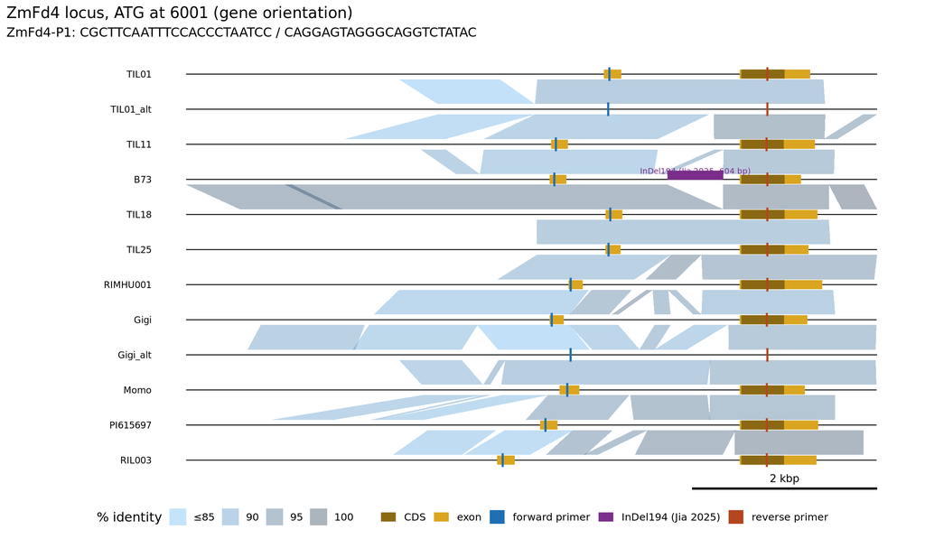

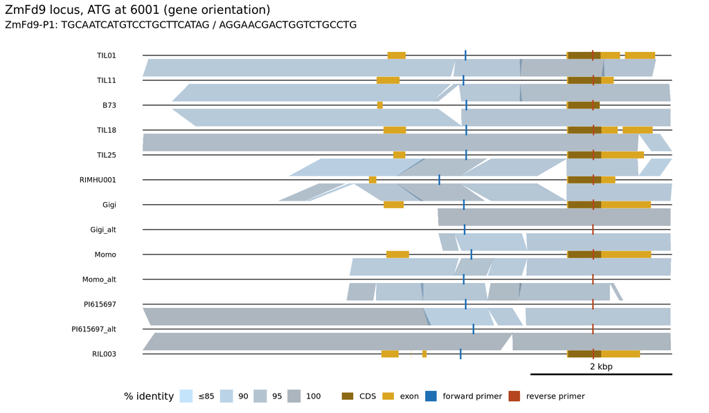

```r
# track order: parviglumis above B73, mexicana right below it (so the B73 links show InDel194), then the rest
# by taxon; each accession's alt haplotype right after its primary
TAXON_RANK <- c("parviglumis" = 1, "ssp. mays" = 2, "mexicana" = 3, "huehuetenangensis" = 4, "diploperennis" = 5,
                "nicaraguensis" = 6, "luxurians" = 7)                 # matched against the taxon column
track_order <- function(acc) {
  base <- sub("_alt$", "", acc)
  tx <- ACC$taxon[match(base, ACC$accession)]
  rank <- map_dbl(tx, ~ { r <- TAXON_RANK[sapply(names(TAXON_RANK), grepl, x = .x, fixed = TRUE)]; if (length(r)) r[1] else 99 })
  acc[order(rank, base, grepl("_alt$", acc))]
}
draw_gene <- function(g) {
  ls <- loci[[g]]
  ls <- ls[track_order(names(ls))]
  seqs <- tibble(seq_id = names(ls), length = Biostrings::width(ls))
  ft <- feats %>% filter(gene == g, type %in% c("exon", "CDS")) %>%
    transmute(seq_id = accession, start, end, feat_type = type)
  fp <- final %>% filter(gene == g) %>% slice_head(n = 1)
  prim <- tibble(seq_id = character(), start = integer(), end = integer(), feat_type = character())
  if (nrow(fp)) prim <- map_dfr(names(ls), function(a) {
    s <- ls[[a]]
    if (!nrow(fp)) return(NULL)
    f <- matchPattern(DNAString(fp$F_seq), s, fixed = "subject"); r <- matchPattern(reverseComplement(DNAString(fp$R_seq)), s, fixed = "subject")
    tibble(seq_id = a, start = c(start(f), start(r)), end = c(end(f), end(r)), feat_type = c("forward primer", "reverse primer"))
  })
  # alignment blocks between adjacent tracks from pairwise blastn
  links <- map_dfr(seq_len(length(ls) - 1), function(k) {
    a <- tempfile(fileext = ".fa"); b <- tempfile(fileext = ".fa")
    writeXStringSet(ls[k], a); writeXStringSet(ls[k + 1], b)
    o <- out(sprintf("blastn -query %s -subject %s -evalue 1e-20 -outfmt '6 qstart qend sstart send pident'", a, b))
    if (!length(o)) return(NULL)
    read_tsv(I(o), col_names = c("start","end","start2","end2","pident"), show_col_types = FALSE) %>%
      filter(start2 < end2) %>% mutate(seq_id = names(ls)[k], seq_id2 = names(ls)[k + 1])
  })
  ind <- if (g == "ZmFd4") tibble(seq_id = "B73", start = INDEL194_LOC[1], end = INDEL194_LOC[2], feat_type = "InDel194 (Jia 2025)") else
    tibble(seq_id = character(), start = integer(), end = integer(), feat_type = character())
  gg <- gggenomes(seqs = seqs, feats = list(ft, prim, ind), links = links)
  ymap <- pull_seqs(gg$data) %>% ungroup() %>% select(seq_id, y)
  gg +
    geom_link(aes(fill = pident), alpha = 0.35, colour = NA) +
    geom_seq() + geom_bin_label() +
    geom_feat(data = feats(ft), aes(colour = feat_type), linewidth = 4, position = "identity") +
    geom_feat(data = feats(ind), aes(colour = feat_type, y = y + 0.12, yend = y + 0.12), linewidth = 4, position = "identity") +
    geom_text(data = ind %>% left_join(ymap, by = "seq_id"), aes(x = (start + end) / 2, y = y + 0.24, label = "InDel194 (Jia 2025, 604 bp)"),
              size = 2.6, colour = "#7B2D8B", inherit.aes = FALSE) +
    geom_feat(data = feats(prim), aes(colour = feat_type), linewidth = 6, position = "identity") +
    scale_colour_manual(values = c(exon = "#DAA520", CDS = "#8B6914", "forward primer" = "#1F6FB4", "reverse primer" = "#B4451F",
                                   "InDel194 (Jia 2025)" = "#7B2D8B"), name = NULL) +
    id_scale("fill", name = "% identity") +
    labs(title = sprintf("%s locus, ATG at %d (gene orientation)", g, UP + 1L),
         subtitle = if (nrow(fp)) sprintf("%s: %s / %s", fp$name, fp$F_seq, fp$R_seq) else "no pair passed") +
    theme(legend.position = "bottom")
}
for (g in GENES$gene) { p <- draw_gene(g); ggsave(file.path(RES, sprintf("map_%s.png", g)), p, width = 12, height = 7, dpi = 150); print(p) }
```

```r
n_alt <- orth %>% filter(hap == "alt"); unpl <- orth %>% filter(hap == "primary", placement == "unplaced")
fd4_alleles <- if (exists("indel194")) indel194 %>% mutate(a = case_when(accession == "B73" ~ "Hap1 in B73", TRUE ~ sub(" .*", "", InDel194))) %>%
  count(a) %>% mutate(a = ifelse(a == "Hap1 in B73", a, paste(a, "in teosinte"))) else NULL
pairs_md <- if (nrow(final)) paste0("| Pair | Forward | Reverse | Product (all loci) | Off-locus products* |\n|---|---|---|---|---|\n",
  paste(sprintf("| **%s** | `%s` | `%s` | %s–%s bp | %d |", final$name, final$F_seq, final$R_seq,
                format(final$min_prod, big.mark = ","), format(final$max_prod, big.mark = ","), final$weak_off), collapse = "\n")) else
  "**No pair passed** — see §8 and §9."
cat('::: {#bottom-line-content}\n',
    sprintf("- **Orthologs:** ZmFd4 and ZmFd9 found in all %d genomes by protein reciprocal best hit (§3, tree §3b).", nrow(ACC)),
    if (nrow(n_alt)) sprintf(" Second haplotypes (`alt`): %s.", paste(sprintf("%s %s", taxon_prefix(n_alt$genome), sub("Zm", "", n_alt$gene)), collapse = ", ")) else "",
    if (nrow(unpl)) sprintf(" **Unplaced** (no copy on a chromosome): %s.", paste(sprintf("%s %s", taxon_prefix(unpl$genome), sub("Zm", "", unpl$gene)), collapse = ", ")) else "",
    "\n", if (!is.null(fd4_alleles)) sprintf("- **ZmFd4 InDel194** (alignment over the 604-bp B73 block, §10): %s.\n",
                                             paste(sprintf("%s (%d loci)", fd4_alleles$a, fd4_alleles$n), collapse = ", ")) else "",
    "- **Recommended pairs** — each binds every locus once (both haplotypes), no degenerate bases unless stated, ",
    "no off-locus product with matching 3′ ends in any genome (§8); annotation maps of the products in §9b:\n\n", pairs_md,
    "\n\n<small>* off-locus products with a mismatch in a primer's 3′-most 5 nt (not expected to amplify).</small>\n:::\n",
    '<script>document.getElementById("bottom-line-slot").appendChild(document.getElementById("bottom-line-content"));</script>\n', sep = "")
```

- **Orthologs:** ZmFd4 and ZmFd9 found in all 10 genomes by protein reciprocal best hit (§3, tree §3b). Second haplotypes (`alt`): Zd-Gigi Fd4, Zd-Gigi Fd9, Zd-Momo Fd9, Zn-PI615697 Fd9, Zv-TIL01 Fd4. **Unplaced** (no copy on a chromosome): Zn-PI615697 Fd9.
- **ZmFd4 InDel194** (alignment over the 604-bp B73 block, §10): Hap1 in B73 (1 loci), Hap2 in teosinte (11 loci).
- **Recommended pairs** — each binds every locus once (both haplotypes), no degenerate bases unless stated, no off-locus product with matching 3′ ends in any genome (§8); annotation maps of the products in §9b:

| Pair | Forward | Reverse | Product (all loci) | Off-locus products* |
| --- | --- | --- | --- | --- |
| **ZmFd4-P1** | `CGCTTCAATTTCCACCCTAATCC` | `CAGGAGTAGGGCAGGTCTATAC` | 1,720–2,877 bp | 0 |
| **ZmFd4-P2** | `GTGTTTCTGAATGCGTGTGC` | `CTGTCCTCTGGCACTTGGATC` | 1,301–2,279 bp | 3 |
| **ZmFd9-P1** | `TGCAATCATGTCCTGCTTCATAG` | `AGGAACGACTGGTCTGCCTG` | 1,706–2,193 bp | 0 |

* off-locus products with a mismatch in a primer’s 3′-most 5 nt (not expected to amplify).

## Next / TODO (student)

- Motif scan of the amplified region (FIMO + MAST, JASPAR 2024 CORE Plantae); genome-specific background (`fasta-get-markov`); nitrogen motif set (NLP / NIGT1).
- Variant catalogue and sequence classes of the amplified region; LD among variants.
- Synteny confirmation of orthologs (neighbouring genes), beyond the paralog score guard.
- Population check with the MaizeGDB 2026 teosinte VCFs.